# Risk Factor Analysis

## Outcome Variable

**Outcome Variable:** ever_wasted

## Predictor Variables

**Intervention Variable:** predexfd6

**Adjustment Set:**

- arm
- sex
- brthmon
- W_mage
- meducyrs
- feducyrs
- hhwealth_quart
- hfoodsec
- W_mhtcm
- W_mwtkg
- W_mbmi
- vagbrth
- W_gagebrth
- W_birthwt
- W_birthlen
- W_nrooms
- W_nchldlt5
- month
- W_parity
- impfloor
- impsan
- safeh20
- delta_W_mage
- delta_meducyrs
- delta_feducyrs
- delta_hhwealth_quart
- delta_hfoodsec
- delta_W_mhtcm
- delta_W_mwtkg
- delta_W_mbmi
- delta_vagbrth
- delta_W_gagebrth
- delta_W_birthwt
- delta_W_birthlen
- delta_W_nrooms
- delta_W_nchldlt5
- delta_month
- delta_W_parity
- delta_impfloor
- delta_impsan
- delta_safeh20

## Stratifying Variables

The analysis was stratified on these variable(s):

- agecat
- studyid
- country

## Data Summary

| agecat | studyid | country | predexfd6 | ever_wasted | n_cell | n |
| --- | --- | --- | --- | --- | --- | --- |
| 0-24 months (no birth wast) | ki0047075b-MAL-ED | BANGLADESH | 1 | 0 | 62 | 233 |
| 0-24 months (no birth wast) | ki0047075b-MAL-ED | BANGLADESH | 1 | 1 | 23 | 233 |
| 0-24 months (no birth wast) | ki0047075b-MAL-ED | BANGLADESH | 0 | 0 | 116 | 233 |
| 0-24 months (no birth wast) | ki0047075b-MAL-ED | BANGLADESH | 0 | 1 | 32 | 233 |
| 0-24 months (no birth wast) | ki0047075b-MAL-ED | BRAZIL | 1 | 0 | 29 | 210 |
| 0-24 months (no birth wast) | ki0047075b-MAL-ED | BRAZIL | 1 | 1 | 1 | 210 |
| 0-24 months (no birth wast) | ki0047075b-MAL-ED | BRAZIL | 0 | 0 | 168 | 210 |
| 0-24 months (no birth wast) | ki0047075b-MAL-ED | BRAZIL | 0 | 1 | 12 | 210 |
| 0-24 months (no birth wast) | ki0047075b-MAL-ED | INDIA | 1 | 0 | 10 | 216 |
| 0-24 months (no birth wast) | ki0047075b-MAL-ED | INDIA | 1 | 1 | 1 | 216 |
| 0-24 months (no birth wast) | ki0047075b-MAL-ED | INDIA | 0 | 0 | 126 | 216 |
| 0-24 months (no birth wast) | ki0047075b-MAL-ED | INDIA | 0 | 1 | 79 | 216 |
| 0-24 months (no birth wast) | ki0047075b-MAL-ED | NEPAL | 1 | 0 | 10 | 225 |
| 0-24 months (no birth wast) | ki0047075b-MAL-ED | NEPAL | 1 | 1 | 2 | 225 |
| 0-24 months (no birth wast) | ki0047075b-MAL-ED | NEPAL | 0 | 0 | 169 | 225 |
| 0-24 months (no birth wast) | ki0047075b-MAL-ED | NEPAL | 0 | 1 | 44 | 225 |
| 0-24 months (no birth wast) | ki0047075b-MAL-ED | PERU | 1 | 0 | 87 | 271 |
| 0-24 months (no birth wast) | ki0047075b-MAL-ED | PERU | 1 | 1 | 5 | 271 |
| 0-24 months (no birth wast) | ki0047075b-MAL-ED | PERU | 0 | 0 | 163 | 271 |
| 0-24 months (no birth wast) | ki0047075b-MAL-ED | PERU | 0 | 1 | 16 | 271 |
| 0-24 months (no birth wast) | ki0047075b-MAL-ED | SOUTH AFRICA | 1 | 0 | 3 | 237 |
| 0-24 months (no birth wast) | ki0047075b-MAL-ED | SOUTH AFRICA | 1 | 1 | 0 | 237 |
| 0-24 months (no birth wast) | ki0047075b-MAL-ED | SOUTH AFRICA | 0 | 0 | 193 | 237 |
| 0-24 months (no birth wast) | ki0047075b-MAL-ED | SOUTH AFRICA | 0 | 1 | 41 | 237 |
| 0-24 months (no birth wast) | ki0047075b-MAL-ED | TANZANIA, UNITED REPUBLIC OF | 1 | 0 | 1 | 235 |
| 0-24 months (no birth wast) | ki0047075b-MAL-ED | TANZANIA, UNITED REPUBLIC OF | 1 | 1 | 0 | 235 |
| 0-24 months (no birth wast) | ki0047075b-MAL-ED | TANZANIA, UNITED REPUBLIC OF | 0 | 0 | 201 | 235 |
| 0-24 months (no birth wast) | ki0047075b-MAL-ED | TANZANIA, UNITED REPUBLIC OF | 0 | 1 | 33 | 235 |
| 0-24 months (no birth wast) | ki1000108-CMC-V-BCS-2002 | INDIA | 1 | 0 | 11 | 19 |
| 0-24 months (no birth wast) | ki1000108-CMC-V-BCS-2002 | INDIA | 1 | 1 | 8 | 19 |

[output cut: 186 more lines]

The following strata were considered:

- agecat: 0-24 months (no birth wast), studyid: ki0047075b-MAL-ED, country: BANGLADESH
- agecat: 0-24 months (no birth wast), studyid: ki0047075b-MAL-ED, country: BRAZIL
- agecat: 0-24 months (no birth wast), studyid: ki0047075b-MAL-ED, country: INDIA
- agecat: 0-24 months (no birth wast), studyid: ki0047075b-MAL-ED, country: NEPAL
- agecat: 0-24 months (no birth wast), studyid: ki0047075b-MAL-ED, country: PERU
- agecat: 0-24 months (no birth wast), studyid: ki0047075b-MAL-ED, country: SOUTH AFRICA
- agecat: 0-24 months (no birth wast), studyid: ki0047075b-MAL-ED, country: TANZANIA, UNITED REPUBLIC OF
- agecat: 0-24 months (no birth wast), studyid: ki1000108-CMC-V-BCS-2002, country: INDIA
- agecat: 0-24 months (no birth wast), studyid: ki1000108-IRC, country: INDIA
- agecat: 0-24 months (no birth wast), studyid: ki1000109-EE, country: PAKISTAN
- agecat: 0-24 months (no birth wast), studyid: ki1000304b-SAS-CompFeed, country: INDIA
- agecat: 0-24 months (no birth wast), studyid: ki1000304b-SAS-FoodSuppl, country: INDIA
- agecat: 0-24 months (no birth wast), studyid: ki1017093b-PROVIDE, country: BANGLADESH
- agecat: 0-24 months (no birth wast), studyid: ki1101329-Keneba, country: GAMBIA
- agecat: 0-24 months (no birth wast), studyid: ki1113344-GMS-Nepal, country: NEPAL
- agecat: 0-24 months (no birth wast), studyid: ki1148112-LCNI-5, country: MALAWI
- agecat: 0-24 months (no birth wast), studyid: kiGH5241-JiVitA-3, country: BANGLADESH
- agecat: 0-24 months (no birth wast), studyid: kiGH5241-JiVitA-4, country: BANGLADESH
- agecat: 0-6 months (no birth wast), studyid: ki0047075b-MAL-ED, country: BANGLADESH
- agecat: 0-6 months (no birth wast), studyid: ki0047075b-MAL-ED, country: BRAZIL
- agecat: 0-6 months (no birth wast), studyid: ki0047075b-MAL-ED, country: INDIA
- agecat: 0-6 months (no birth wast), studyid: ki0047075b-MAL-ED, country: NEPAL
- agecat: 0-6 months (no birth wast), studyid: ki0047075b-MAL-ED, country: PERU
- agecat: 0-6 months (no birth wast), studyid: ki0047075b-MAL-ED, country: SOUTH AFRICA
- agecat: 0-6 months (no birth wast), studyid: ki0047075b-MAL-ED, country: TANZANIA, UNITED REPUBLIC OF
- agecat: 0-6 months (no birth wast), studyid: ki1000108-CMC-V-BCS-2002, country: INDIA
- agecat: 0-6 months (no birth wast), studyid: ki1000108-IRC, country: INDIA
- agecat: 0-6 months (no birth wast), studyid: ki1000109-EE, country: PAKISTAN
- agecat: 0-6 months (no birth wast), studyid: ki1000304b-SAS-CompFeed, country: INDIA
- agecat: 0-6 months (no birth wast), studyid: ki1000304b-SAS-FoodSuppl, country: INDIA
- agecat: 0-6 months (no birth wast), studyid: ki1017093b-PROVIDE, country: BANGLADESH
- agecat: 0-6 months (no birth wast), studyid: ki1101329-Keneba, country: GAMBIA
- agecat: 0-6 months (no birth wast), studyid: ki1113344-GMS-Nepal, country: NEPAL
- agecat: 0-6 months (no birth wast), studyid: ki1148112-LCNI-5, country: MALAWI
- agecat: 0-6 months (no birth wast), studyid: kiGH5241-JiVitA-3, country: BANGLADESH
- agecat: 0-6 months (no birth wast), studyid: kiGH5241-JiVitA-4, country: BANGLADESH
- agecat: 6-24 months, studyid: ki0047075b-MAL-ED, country: BANGLADESH
- agecat: 6-24 months, studyid: ki0047075b-MAL-ED, country: BRAZIL
- agecat: 6-24 months, studyid: ki0047075b-MAL-ED, country: INDIA
- agecat: 6-24 months, studyid: ki0047075b-MAL-ED, country: NEPAL
- agecat: 6-24 months, studyid: ki0047075b-MAL-ED, country: PERU
- agecat: 6-24 months, studyid: ki0047075b-MAL-ED, country: SOUTH AFRICA
- agecat: 6-24 months, studyid: ki0047075b-MAL-ED, country: TANZANIA, UNITED REPUBLIC OF
- agecat: 6-24 months, studyid: ki1000108-CMC-V-BCS-2002, country: INDIA
- agecat: 6-24 months, studyid: ki1000108-IRC, country: INDIA
- agecat: 6-24 months, studyid: ki1000109-EE, country: PAKISTAN
- agecat: 6-24 months, studyid: ki1000304b-SAS-CompFeed, country: INDIA
- agecat: 6-24 months, studyid: ki1000304b-SAS-FoodSuppl, country: INDIA
- agecat: 6-24 months, studyid: ki1017093b-PROVIDE, country: BANGLADESH
- agecat: 6-24 months, studyid: ki1101329-Keneba, country: GAMBIA
- agecat: 6-24 months, studyid: ki1113344-GMS-Nepal, country: NEPAL
- agecat: 6-24 months, studyid: ki1148112-LCNI-5, country: MALAWI
- agecat: 6-24 months, studyid: kiGH5241-JiVitA-3, country: BANGLADESH
- agecat: 6-24 months, studyid: kiGH5241-JiVitA-4, country: BANGLADESH

### Dropped Strata

Some strata were dropped due to rare outcomes:

- agecat: 0-24 months (no birth wast), studyid: ki0047075b-MAL-ED, country: BRAZIL
- agecat: 0-24 months (no birth wast), studyid: ki0047075b-MAL-ED, country: INDIA
- agecat: 0-24 months (no birth wast), studyid: ki0047075b-MAL-ED, country: NEPAL
- agecat: 0-24 months (no birth wast), studyid: ki0047075b-MAL-ED, country: SOUTH AFRICA
- agecat: 0-24 months (no birth wast), studyid: ki0047075b-MAL-ED, country: TANZANIA, UNITED REPUBLIC OF
- agecat: 0-24 months (no birth wast), studyid: ki1000108-CMC-V-BCS-2002, country: INDIA
- agecat: 0-24 months (no birth wast), studyid: ki1000108-IRC, country: INDIA
- agecat: 0-24 months (no birth wast), studyid: ki1000109-EE, country: PAKISTAN
- agecat: 0-24 months (no birth wast), studyid: ki1000304b-SAS-FoodSuppl, country: INDIA
- agecat: 0-6 months (no birth wast), studyid: ki0047075b-MAL-ED, country: BRAZIL
- agecat: 0-6 months (no birth wast), studyid: ki0047075b-MAL-ED, country: INDIA
- agecat: 0-6 months (no birth wast), studyid: ki0047075b-MAL-ED, country: NEPAL
- agecat: 0-6 months (no birth wast), studyid: ki0047075b-MAL-ED, country: PERU
- agecat: 0-6 months (no birth wast), studyid: ki0047075b-MAL-ED, country: SOUTH AFRICA
- agecat: 0-6 months (no birth wast), studyid: ki0047075b-MAL-ED, country: TANZANIA, UNITED REPUBLIC OF
- agecat: 0-6 months (no birth wast), studyid: ki1000108-CMC-V-BCS-2002, country: INDIA
- agecat: 0-6 months (no birth wast), studyid: ki1000108-IRC, country: INDIA
- agecat: 0-6 months (no birth wast), studyid: ki1000109-EE, country: PAKISTAN
- agecat: 0-6 months (no birth wast), studyid: ki1000304b-SAS-FoodSuppl, country: INDIA
- agecat: 0-6 months (no birth wast), studyid: ki1148112-LCNI-5, country: MALAWI
- agecat: 6-24 months, studyid: ki0047075b-MAL-ED, country: BRAZIL
- agecat: 6-24 months, studyid: ki0047075b-MAL-ED, country: INDIA
- agecat: 6-24 months, studyid: ki0047075b-MAL-ED, country: NEPAL
- agecat: 6-24 months, studyid: ki0047075b-MAL-ED, country: PERU
- agecat: 6-24 months, studyid: ki0047075b-MAL-ED, country: SOUTH AFRICA
- agecat: 6-24 months, studyid: ki0047075b-MAL-ED, country: TANZANIA, UNITED REPUBLIC OF
- agecat: 6-24 months, studyid: ki1000108-CMC-V-BCS-2002, country: INDIA
- agecat: 6-24 months, studyid: ki1000108-IRC, country: INDIA
- agecat: 6-24 months, studyid: ki1000109-EE, country: PAKISTAN
- agecat: 6-24 months, studyid: ki1000304b-SAS-FoodSuppl, country: INDIA

## Methods Detail

We’re interested in the causal parameters $E[Y_a]$ for all values of $a \in \mathcal{A}$. These parameters represent the mean outcome if, possibly contrary to fact, we intervened to set all units to have $A=a$. Under the randomization and positivity assumptions, these are identified by the statistical parameters $\psi_a=E_W[E_{Y|A,W}(Y|A=a,W)]$. In addition, we’re interested in the mean of $Y$, $E[Y]$ under no intervention (the observed mean). We will estimate these parameters by using SuperLearner to fit the relevant likelihood factors – $E_{Y|A,W}(Y|A=a,W)$ and $p(A=a|W)$, and then updating our likelihood fit using a joint TMLE.

For unadjusted analyses ($W=\{\}$), initial likelihoods were estimated using Lrnr_glm to estimate the simple $E(Y|A)$ and Lrnr_mean to estimate $p(A)$. For adjusted analyses, a small library containing Lrnr_glmnet, Lrnr_xgboost, and Lrnr_mean was used.

Having estimated these parameters, we will then use the delta method to estimate relative risks and attributable risks relative to a prespecified baseline level of $A$.

# Results Detail

## Results Plots

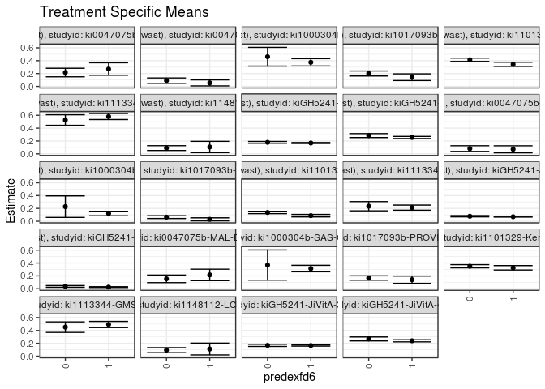

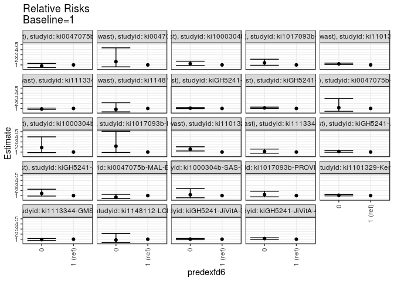

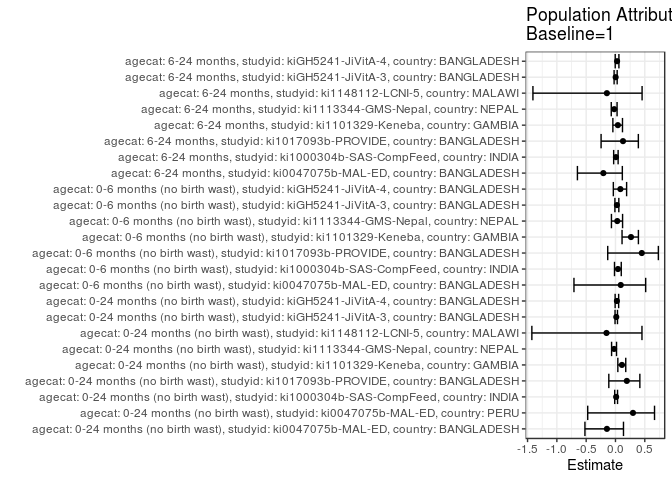

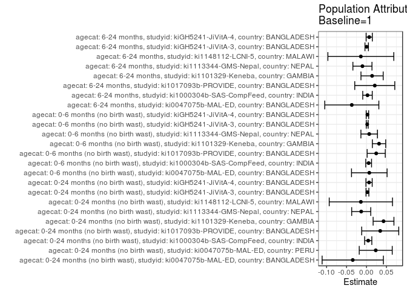

## Results Table

### Parameter: TSM

| agecat | studyid | country | intervention_level | baseline_level | estimate | ci_lower | ci_upper |
| --- | --- | --- | --- | --- | --- | --- | --- |
| 0-24 months (no birth wast) | ki0047075b-MAL-ED | BANGLADESH | 1 | NA | 0.2704997 | 0.1730834 | 0.3679160 |
| 0-24 months (no birth wast) | ki0047075b-MAL-ED | BANGLADESH | 0 | NA | 0.2156063 | 0.1488951 | 0.2823175 |
| 0-24 months (no birth wast) | ki0047075b-MAL-ED | PERU | 1 | NA | 0.0543478 | 0.0079376 | 0.1007581 |
| 0-24 months (no birth wast) | ki0047075b-MAL-ED | PERU | 0 | NA | 0.0893855 | 0.0475133 | 0.1312576 |
| 0-24 months (no birth wast) | ki1000304b-SAS-CompFeed | INDIA | 1 | NA | 0.3749192 | 0.3179202 | 0.4319182 |
| 0-24 months (no birth wast) | ki1000304b-SAS-CompFeed | INDIA | 0 | NA | 0.4616077 | 0.3160034 | 0.6072119 |
| 0-24 months (no birth wast) | ki1017093b-PROVIDE | BANGLADESH | 1 | NA | 0.1432151 | 0.0910832 | 0.1953470 |
| 0-24 months (no birth wast) | ki1017093b-PROVIDE | BANGLADESH | 0 | NA | 0.2007523 | 0.1618366 | 0.2396681 |
| 0-24 months (no birth wast) | ki1101329-Keneba | GAMBIA | 1 | NA | 0.3441186 | 0.3117589 | 0.3764783 |
| 0-24 months (no birth wast) | ki1101329-Keneba | GAMBIA | 0 | NA | 0.4144119 | 0.3887480 | 0.4400759 |
| 0-24 months (no birth wast) | ki1113344-GMS-Nepal | NEPAL | 1 | NA | 0.5811104 | 0.5339342 | 0.6282866 |
| 0-24 months (no birth wast) | ki1113344-GMS-Nepal | NEPAL | 0 | NA | 0.5262718 | 0.4441142 | 0.6084294 |
| 0-24 months (no birth wast) | ki1148112-LCNI-5 | MALAWI | 1 | NA | 0.1063830 | 0.0180722 | 0.1946938 |
| 0-24 months (no birth wast) | ki1148112-LCNI-5 | MALAWI | 0 | NA | 0.0892857 | 0.0518739 | 0.1266975 |
| 0-24 months (no birth wast) | kiGH5241-JiVitA-3 | BANGLADESH | 1 | NA | 0.1685434 | 0.1613704 | 0.1757163 |
| 0-24 months (no birth wast) | kiGH5241-JiVitA-3 | BANGLADESH | 0 | NA | 0.1790238 | 0.1647860 | 0.1932617 |
| 0-24 months (no birth wast) | kiGH5241-JiVitA-4 | BANGLADESH | 1 | NA | 0.2546929 | 0.2379550 | 0.2714307 |
| 0-24 months (no birth wast) | kiGH5241-JiVitA-4 | BANGLADESH | 0 | NA | 0.2840611 | 0.2532576 | 0.3148646 |
| 0-6 months (no birth wast) | ki0047075b-MAL-ED | BANGLADESH | 1 | NA | 0.0705882 | 0.0160191 | 0.1251573 |
| 0-6 months (no birth wast) | ki0047075b-MAL-ED | BANGLADESH | 0 | NA | 0.0816327 | 0.0372751 | 0.1259902 |
| 0-6 months (no birth wast) | ki1000304b-SAS-CompFeed | INDIA | 1 | NA | 0.1204819 | 0.0857775 | 0.1551864 |
| 0-6 months (no birth wast) | ki1000304b-SAS-CompFeed | INDIA | 0 | NA | 0.2272727 | 0.0595457 | 0.3949997 |
| 0-6 months (no birth wast) | ki1017093b-PROVIDE | BANGLADESH | 1 | NA | 0.0298507 | 0.0063076 | 0.0533939 |
| 0-6 months (no birth wast) | ki1017093b-PROVIDE | BANGLADESH | 0 | NA | 0.0643154 | 0.0423992 | 0.0862315 |
| 0-6 months (no birth wast) | ki1101329-Keneba | GAMBIA | 1 | NA | 0.0871592 | 0.0676905 | 0.1066278 |
| 0-6 months (no birth wast) | ki1101329-Keneba | GAMBIA | 0 | NA | 0.1369892 | 0.1188637 | 0.1551148 |
| 0-6 months (no birth wast) | ki1113344-GMS-Nepal | NEPAL | 1 | NA | 0.2120024 | 0.1721652 | 0.2518396 |
| 0-6 months (no birth wast) | ki1113344-GMS-Nepal | NEPAL | 0 | NA | 0.2344800 | 0.1625866 | 0.3063734 |
| 0-6 months (no birth wast) | kiGH5241-JiVitA-3 | BANGLADESH | 1 | NA | 0.0701601 | 0.0650381 | 0.0752821 |
| 0-6 months (no birth wast) | kiGH5241-JiVitA-3 | BANGLADESH | 0 | NA | 0.0782158 | 0.0683964 | 0.0880351 |
| 0-6 months (no birth wast) | kiGH5241-JiVitA-4 | BANGLADESH | 1 | NA | 0.0251358 | 0.0190504 | 0.0312212 |
| 0-6 months (no birth wast) | kiGH5241-JiVitA-4 | BANGLADESH | 0 | NA | 0.0361123 | 0.0228522 | 0.0493725 |
| 6-24 months | ki0047075b-MAL-ED | BANGLADESH | 1 | NA | 0.2151206 | 0.1260215 | 0.3042198 |
| 6-24 months | ki0047075b-MAL-ED | BANGLADESH | 0 | NA | 0.1537620 | 0.0944939 | 0.2130301 |
| 6-24 months | ki1000304b-SAS-CompFeed | INDIA | 1 | NA | 0.3140704 | 0.2638452 | 0.3642955 |
| 6-24 months | ki1000304b-SAS-CompFeed | INDIA | 0 | NA | 0.3684211 | 0.1333387 | 0.6035034 |
| 6-24 months | ki1017093b-PROVIDE | BANGLADESH | 1 | NA | 0.1402803 | 0.0837041 | 0.1968565 |
| 6-24 months | ki1017093b-PROVIDE | BANGLADESH | 0 | NA | 0.1667188 | 0.1328402 | 0.2005974 |
| 6-24 months | ki1101329-Keneba | GAMBIA | 1 | NA | 0.3257554 | 0.2915923 | 0.3599184 |
| 6-24 months | ki1101329-Keneba | GAMBIA | 0 | NA | 0.3497178 | 0.3245070 | 0.3749286 |
| 6-24 months | ki1113344-GMS-Nepal | NEPAL | 1 | NA | 0.4931576 | 0.4452511 | 0.5410641 |
| 6-24 months | ki1113344-GMS-Nepal | NEPAL | 0 | NA | 0.4521308 | 0.3700477 | 0.5342139 |
| 6-24 months | ki1148112-LCNI-5 | MALAWI | 1 | NA | 0.1111111 | 0.0191112 | 0.2031111 |
| 6-24 months | ki1148112-LCNI-5 | MALAWI | 0 | NA | 0.0938967 | 0.0546489 | 0.1331445 |
| 6-24 months | kiGH5241-JiVitA-3 | BANGLADESH | 1 | NA | 0.1655462 | 0.1566506 | 0.1744419 |
| 6-24 months | kiGH5241-JiVitA-3 | BANGLADESH | 0 | NA | 0.1682133 | 0.1515493 | 0.1848773 |
| 6-24 months | kiGH5241-JiVitA-4 | BANGLADESH | 1 | NA | 0.2395138 | 0.2230838 | 0.2559437 |
| 6-24 months | kiGH5241-JiVitA-4 | BANGLADESH | 0 | NA | 0.2680927 | 0.2371688 | 0.2990166 |

### Parameter: E(Y)

| agecat | studyid | country | intervention_level | baseline_level | estimate | ci_lower | ci_upper |
| --- | --- | --- | --- | --- | --- | --- | --- |
| 0-24 months (no birth wast) | ki0047075b-MAL-ED | BANGLADESH | NA | NA | 0.2360515 | 0.1814079 | 0.2906951 |
| 0-24 months (no birth wast) | ki0047075b-MAL-ED | PERU | NA | NA | 0.0774908 | 0.0455992 | 0.1093824 |
| 0-24 months (no birth wast) | ki1000304b-SAS-CompFeed | INDIA | NA | NA | 0.3792325 | 0.3255512 | 0.4329138 |
| 0-24 months (no birth wast) | ki1017093b-PROVIDE | BANGLADESH | NA | NA | 0.1775837 | 0.1489858 | 0.2061816 |
| 0-24 months (no birth wast) | ki1101329-Keneba | GAMBIA | NA | NA | 0.3867925 | 0.3665564 | 0.4070285 |
| 0-24 months (no birth wast) | ki1113344-GMS-Nepal | NEPAL | NA | NA | 0.5678571 | 0.5267918 | 0.6089225 |
| 0-24 months (no birth wast) | ki1148112-LCNI-5 | MALAWI | NA | NA | 0.0922509 | 0.0577338 | 0.1267680 |
| 0-24 months (no birth wast) | kiGH5241-JiVitA-3 | BANGLADESH | NA | NA | 0.1708796 | 0.1645476 | 0.1772116 |
| 0-24 months (no birth wast) | kiGH5241-JiVitA-4 | BANGLADESH | NA | NA | 0.2611182 | 0.2462845 | 0.2759518 |
| 0-6 months (no birth wast) | ki0047075b-MAL-ED | BANGLADESH | NA | NA | 0.0775862 | 0.0430879 | 0.1120845 |
| 0-6 months (no birth wast) | ki1000304b-SAS-CompFeed | INDIA | NA | NA | 0.1258581 | 0.0910745 | 0.1606418 |
| 0-6 months (no birth wast) | ki1017093b-PROVIDE | BANGLADESH | NA | NA | 0.0541728 | 0.0371844 | 0.0711612 |
| 0-6 months (no birth wast) | ki1101329-Keneba | GAMBIA | NA | NA | 0.1185520 | 0.1050716 | 0.1320324 |
| 0-6 months (no birth wast) | ki1113344-GMS-Nepal | NEPAL | NA | NA | 0.2187500 | 0.1839790 | 0.2535210 |
| 0-6 months (no birth wast) | kiGH5241-JiVitA-3 | BANGLADESH | NA | NA | 0.0719114 | 0.0672720 | 0.0765508 |
| 0-6 months (no birth wast) | kiGH5241-JiVitA-4 | BANGLADESH | NA | NA | 0.0274331 | 0.0219967 | 0.0328694 |
| 6-24 months | ki0047075b-MAL-ED | BANGLADESH | NA | NA | 0.1782609 | 0.1286901 | 0.2278316 |
| 6-24 months | ki1000304b-SAS-CompFeed | INDIA | NA | NA | 0.3165468 | 0.2711185 | 0.3619751 |
| 6-24 months | ki1017093b-PROVIDE | BANGLADESH | NA | NA | 0.1609756 | 0.1319065 | 0.1900447 |
| 6-24 months | ki1101329-Keneba | GAMBIA | NA | NA | 0.3397129 | 0.3194033 | 0.3600225 |
| 6-24 months | ki1113344-GMS-Nepal | NEPAL | NA | NA | 0.4829443 | 0.4414080 | 0.5244807 |
| 6-24 months | ki1148112-LCNI-5 | MALAWI | NA | NA | 0.0968992 | 0.0607324 | 0.1330660 |
| 6-24 months | kiGH5241-JiVitA-3 | BANGLADESH | NA | NA | 0.1660459 | 0.1583106 | 0.1737812 |
| 6-24 months | kiGH5241-JiVitA-4 | BANGLADESH | NA | NA | 0.2463096 | 0.2316309 | 0.2609882 |

### Parameter: RR

| agecat | studyid | country | intervention_level | baseline_level | estimate | ci_lower | ci_upper |
| --- | --- | --- | --- | --- | --- | --- | --- |
| 0-24 months (no birth wast) | ki0047075b-MAL-ED | BANGLADESH | 1 | 1 | 1.0000000 | 1.0000000 | 1.000000 |
| 0-24 months (no birth wast) | ki0047075b-MAL-ED | BANGLADESH | 0 | 1 | 0.7970669 | 0.4971299 | 1.277967 |
| 0-24 months (no birth wast) | ki0047075b-MAL-ED | PERU | 1 | 1 | 1.0000000 | 1.0000000 | 1.000000 |
| 0-24 months (no birth wast) | ki0047075b-MAL-ED | PERU | 0 | 1 | 1.6446927 | 0.6209888 | 4.355979 |
| 0-24 months (no birth wast) | ki1000304b-SAS-CompFeed | INDIA | 1 | 1 | 1.0000000 | 1.0000000 | 1.000000 |
| 0-24 months (no birth wast) | ki1000304b-SAS-CompFeed | INDIA | 0 | 1 | 1.2312191 | 0.8795361 | 1.723523 |
| 0-24 months (no birth wast) | ki1017093b-PROVIDE | BANGLADESH | 1 | 1 | 1.0000000 | 1.0000000 | 1.000000 |
| 0-24 months (no birth wast) | ki1017093b-PROVIDE | BANGLADESH | 0 | 1 | 1.4017543 | 0.9276525 | 2.118158 |
| 0-24 months (no birth wast) | ki1101329-Keneba | GAMBIA | 1 | 1 | 1.0000000 | 1.0000000 | 1.000000 |
| 0-24 months (no birth wast) | ki1101329-Keneba | GAMBIA | 0 | 1 | 1.2042706 | 1.0769000 | 1.346706 |
| 0-24 months (no birth wast) | ki1113344-GMS-Nepal | NEPAL | 1 | 1 | 1.0000000 | 1.0000000 | 1.000000 |
| 0-24 months (no birth wast) | ki1113344-GMS-Nepal | NEPAL | 0 | 1 | 0.9056313 | 0.7604359 | 1.078550 |
| 0-24 months (no birth wast) | ki1148112-LCNI-5 | MALAWI | 1 | 1 | 1.0000000 | 1.0000000 | 1.000000 |
| 0-24 months (no birth wast) | ki1148112-LCNI-5 | MALAWI | 0 | 1 | 0.8392857 | 0.3311837 | 2.126918 |
| 0-24 months (no birth wast) | kiGH5241-JiVitA-3 | BANGLADESH | 1 | 1 | 1.0000000 | 1.0000000 | 1.000000 |
| 0-24 months (no birth wast) | kiGH5241-JiVitA-3 | BANGLADESH | 0 | 1 | 1.0621826 | 0.9696145 | 1.163588 |
| 0-24 months (no birth wast) | kiGH5241-JiVitA-4 | BANGLADESH | 1 | 1 | 1.0000000 | 1.0000000 | 1.000000 |
| 0-24 months (no birth wast) | kiGH5241-JiVitA-4 | BANGLADESH | 0 | 1 | 1.1153085 | 0.9834582 | 1.264836 |
| 0-6 months (no birth wast) | ki0047075b-MAL-ED | BANGLADESH | 1 | 1 | 1.0000000 | 1.0000000 | 1.000000 |
| 0-6 months (no birth wast) | ki0047075b-MAL-ED | BANGLADESH | 0 | 1 | 1.1564626 | 0.4495261 | 2.975146 |
| 0-6 months (no birth wast) | ki1000304b-SAS-CompFeed | INDIA | 1 | 1 | 1.0000000 | 1.0000000 | 1.000000 |
| 0-6 months (no birth wast) | ki1000304b-SAS-CompFeed | INDIA | 0 | 1 | 1.8863636 | 0.8915751 | 3.991103 |
| 0-6 months (no birth wast) | ki1017093b-PROVIDE | BANGLADESH | 1 | 1 | 1.0000000 | 1.0000000 | 1.000000 |
| 0-6 months (no birth wast) | ki1017093b-PROVIDE | BANGLADESH | 0 | 1 | 2.1545643 | 0.9124937 | 5.087320 |
| 0-6 months (no birth wast) | ki1101329-Keneba | GAMBIA | 1 | 1 | 1.0000000 | 1.0000000 | 1.000000 |
| 0-6 months (no birth wast) | ki1101329-Keneba | GAMBIA | 0 | 1 | 1.5717137 | 1.2134629 | 2.035731 |
| 0-6 months (no birth wast) | ki1113344-GMS-Nepal | NEPAL | 1 | 1 | 1.0000000 | 1.0000000 | 1.000000 |
| 0-6 months (no birth wast) | ki1113344-GMS-Nepal | NEPAL | 0 | 1 | 1.1060253 | 0.7718090 | 1.584967 |
| 0-6 months (no birth wast) | kiGH5241-JiVitA-3 | BANGLADESH | 1 | 1 | 1.0000000 | 1.0000000 | 1.000000 |
| 0-6 months (no birth wast) | kiGH5241-JiVitA-3 | BANGLADESH | 0 | 1 | 1.1148179 | 0.9671192 | 1.285073 |
| 0-6 months (no birth wast) | kiGH5241-JiVitA-4 | BANGLADESH | 1 | 1 | 1.0000000 | 1.0000000 | 1.000000 |
| 0-6 months (no birth wast) | kiGH5241-JiVitA-4 | BANGLADESH | 0 | 1 | 1.4366878 | 0.9149332 | 2.255981 |
| 6-24 months | ki0047075b-MAL-ED | BANGLADESH | 1 | 1 | 1.0000000 | 1.0000000 | 1.000000 |
| 6-24 months | ki0047075b-MAL-ED | BANGLADESH | 0 | 1 | 0.7147710 | 0.4062304 | 1.257655 |
| 6-24 months | ki1000304b-SAS-CompFeed | INDIA | 1 | 1 | 1.0000000 | 1.0000000 | 1.000000 |
| 6-24 months | ki1000304b-SAS-CompFeed | INDIA | 0 | 1 | 1.1730526 | 0.5767231 | 2.385985 |
| 6-24 months | ki1017093b-PROVIDE | BANGLADESH | 1 | 1 | 1.0000000 | 1.0000000 | 1.000000 |
| 6-24 months | ki1017093b-PROVIDE | BANGLADESH | 0 | 1 | 1.1884690 | 0.7563416 | 1.867488 |
| 6-24 months | ki1101329-Keneba | GAMBIA | 1 | 1 | 1.0000000 | 1.0000000 | 1.000000 |
| 6-24 months | ki1101329-Keneba | GAMBIA | 0 | 1 | 1.0735596 | 0.9458563 | 1.218505 |
| 6-24 months | ki1113344-GMS-Nepal | NEPAL | 1 | 1 | 1.0000000 | 1.0000000 | 1.000000 |
| 6-24 months | ki1113344-GMS-Nepal | NEPAL | 0 | 1 | 0.9168079 | 0.7473728 | 1.124655 |
| 6-24 months | ki1148112-LCNI-5 | MALAWI | 1 | 1 | 1.0000000 | 1.0000000 | 1.000000 |
| 6-24 months | ki1148112-LCNI-5 | MALAWI | 0 | 1 | 0.8450704 | 0.3342527 | 2.136539 |
| 6-24 months | kiGH5241-JiVitA-3 | BANGLADESH | 1 | 1 | 1.0000000 | 1.0000000 | 1.000000 |
| 6-24 months | kiGH5241-JiVitA-3 | BANGLADESH | 0 | 1 | 1.0161107 | 0.9063319 | 1.139186 |
| 6-24 months | kiGH5241-JiVitA-4 | BANGLADESH | 1 | 1 | 1.0000000 | 1.0000000 | 1.000000 |
| 6-24 months | kiGH5241-JiVitA-4 | BANGLADESH | 0 | 1 | 1.1193206 | 0.9809323 | 1.277232 |

### Parameter: PAR

| agecat | studyid | country | intervention_level | baseline_level | estimate | ci_lower | ci_upper |
| --- | --- | --- | --- | --- | --- | --- | --- |
| 0-24 months (no birth wast) | ki0047075b-MAL-ED | BANGLADESH | 1 | NA | -0.0344482 | -0.1112184 | 0.0423221 |
| 0-24 months (no birth wast) | ki0047075b-MAL-ED | PERU | 1 | NA | 0.0231429 | -0.0181917 | 0.0644776 |
| 0-24 months (no birth wast) | ki1000304b-SAS-CompFeed | INDIA | 1 | NA | 0.0043133 | -0.0046855 | 0.0133121 |
| 0-24 months (no birth wast) | ki1017093b-PROVIDE | BANGLADESH | 1 | NA | 0.0343686 | -0.0120560 | 0.0807932 |
| 0-24 months (no birth wast) | ki1101329-Keneba | GAMBIA | 1 | NA | 0.0426738 | 0.0166055 | 0.0687421 |
| 0-24 months (no birth wast) | ki1113344-GMS-Nepal | NEPAL | 1 | NA | -0.0132533 | -0.0371384 | 0.0106318 |
| 0-24 months (no birth wast) | ki1148112-LCNI-5 | MALAWI | 1 | NA | -0.0141321 | -0.0934107 | 0.0651466 |
| 0-24 months (no birth wast) | kiGH5241-JiVitA-3 | BANGLADESH | 1 | NA | 0.0023362 | -0.0012232 | 0.0058957 |
| 0-24 months (no birth wast) | kiGH5241-JiVitA-4 | BANGLADESH | 1 | NA | 0.0064253 | -0.0014021 | 0.0142528 |
| 0-6 months (no birth wast) | ki0047075b-MAL-ED | BANGLADESH | 1 | NA | 0.0069980 | -0.0375657 | 0.0515616 |
| 0-6 months (no birth wast) | ki1000304b-SAS-CompFeed | INDIA | 1 | NA | 0.0053762 | -0.0018898 | 0.0126422 |
| 0-6 months (no birth wast) | ki1017093b-PROVIDE | BANGLADESH | 1 | NA | 0.0243220 | 0.0015921 | 0.0470519 |
| 0-6 months (no birth wast) | ki1101329-Keneba | GAMBIA | 1 | NA | 0.0313929 | 0.0146763 | 0.0481094 |
| 0-6 months (no birth wast) | ki1113344-GMS-Nepal | NEPAL | 1 | NA | 0.0067476 | -0.0140078 | 0.0275030 |
| 0-6 months (no birth wast) | kiGH5241-JiVitA-3 | BANGLADESH | 1 | NA | 0.0017513 | -0.0006519 | 0.0041545 |
| 0-6 months (no birth wast) | kiGH5241-JiVitA-4 | BANGLADESH | 1 | NA | 0.0022972 | -0.0007970 | 0.0053914 |
| 6-24 months | ki0047075b-MAL-ED | BANGLADESH | 1 | NA | -0.0368598 | -0.1046397 | 0.0309202 |
| 6-24 months | ki1000304b-SAS-CompFeed | INDIA | 1 | NA | 0.0024764 | -0.0094430 | 0.0143959 |
| 6-24 months | ki1017093b-PROVIDE | BANGLADESH | 1 | NA | 0.0206953 | -0.0294657 | 0.0708563 |
| 6-24 months | ki1101329-Keneba | GAMBIA | 1 | NA | 0.0139576 | -0.0138879 | 0.0418030 |
| 6-24 months | ki1113344-GMS-Nepal | NEPAL | 1 | NA | -0.0102132 | -0.0341136 | 0.0136872 |
| 6-24 months | ki1148112-LCNI-5 | MALAWI | 1 | NA | -0.0142119 | -0.0967920 | 0.0683682 |
| 6-24 months | kiGH5241-JiVitA-3 | BANGLADESH | 1 | NA | 0.0004996 | -0.0038473 | 0.0048466 |
| 6-24 months | kiGH5241-JiVitA-4 | BANGLADESH | 1 | NA | 0.0067958 | -0.0009581 | 0.0145497 |

### Parameter: PAF

| agecat | studyid | country | intervention_level | baseline_level | estimate | ci_lower | ci_upper |
| --- | --- | --- | --- | --- | --- | --- | --- |
| 0-24 months (no birth wast) | ki0047075b-MAL-ED | BANGLADESH | 1 | NA | -0.1459349 | -0.5210725 | 0.1366836 |
| 0-24 months (no birth wast) | ki0047075b-MAL-ED | PERU | 1 | NA | 0.2986542 | -0.4737013 | 0.6662242 |
| 0-24 months (no birth wast) | ki1000304b-SAS-CompFeed | INDIA | 1 | NA | 0.0113737 | -0.0131809 | 0.0353333 |
| 0-24 months (no birth wast) | ki1017093b-PROVIDE | BANGLADESH | 1 | NA | 0.1935348 | -0.1136576 | 0.4159909 |
| 0-24 months (no birth wast) | ki1101329-Keneba | GAMBIA | 1 | NA | 0.1103275 | 0.0402936 | 0.1752507 |
| 0-24 months (no birth wast) | ki1113344-GMS-Nepal | NEPAL | 1 | NA | -0.0233391 | -0.0663405 | 0.0179282 |
| 0-24 months (no birth wast) | ki1148112-LCNI-5 | MALAWI | 1 | NA | -0.1531915 | -1.4265796 | 0.4519650 |
| 0-24 months (no birth wast) | kiGH5241-JiVitA-3 | BANGLADESH | 1 | NA | 0.0136719 | -0.0073708 | 0.0342751 |
| 0-24 months (no birth wast) | kiGH5241-JiVitA-4 | BANGLADESH | 1 | NA | 0.0246069 | -0.0058616 | 0.0541525 |
| 0-6 months (no birth wast) | ki0047075b-MAL-ED | BANGLADESH | 1 | NA | 0.0901961 | -0.7082806 | 0.5154524 |
| 0-6 months (no birth wast) | ki1000304b-SAS-CompFeed | INDIA | 1 | NA | 0.0427163 | -0.0166271 | 0.0985957 |
| 0-6 months (no birth wast) | ki1017093b-PROVIDE | BANGLADESH | 1 | NA | 0.4489714 | -0.1322414 | 0.7318305 |
| 0-6 months (no birth wast) | ki1101329-Keneba | GAMBIA | 1 | NA | 0.2648025 | 0.1121382 | 0.3912168 |
| 0-6 months (no birth wast) | ki1113344-GMS-Nepal | NEPAL | 1 | NA | 0.0308461 | -0.0687775 | 0.1211835 |
| 0-6 months (no birth wast) | kiGH5241-JiVitA-3 | BANGLADESH | 1 | NA | 0.0243536 | -0.0096047 | 0.0571697 |
| 0-6 months (no birth wast) | kiGH5241-JiVitA-4 | BANGLADESH | 1 | NA | 0.0837389 | -0.0365000 | 0.1900296 |
| 6-24 months | ki0047075b-MAL-ED | BANGLADESH | 1 | NA | -0.2067744 | -0.6492649 | 0.1169979 |
| 6-24 months | ki1000304b-SAS-CompFeed | INDIA | 1 | NA | 0.0078232 | -0.0309120 | 0.0451030 |
| 6-24 months | ki1017093b-PROVIDE | BANGLADESH | 1 | NA | 0.1285616 | -0.2454472 | 0.3902553 |
| 6-24 months | ki1101329-Keneba | GAMBIA | 1 | NA | 0.0410863 | -0.0444775 | 0.1196407 |
| 6-24 months | ki1113344-GMS-Nepal | NEPAL | 1 | NA | -0.0211478 | -0.0718921 | 0.0271941 |
| 6-24 months | ki1148112-LCNI-5 | MALAWI | 1 | NA | -0.1466667 | -1.4083049 | 0.4540374 |
| 6-24 months | kiGH5241-JiVitA-3 | BANGLADESH | 1 | NA | 0.0030090 | -0.0235182 | 0.0288486 |
| 6-24 months | kiGH5241-JiVitA-4 | BANGLADESH | 1 | NA | 0.0275905 | -0.0044071 | 0.0585688 |